# Dimensionality reduction techniques

## Visualization and interpretation of MCA

We’ll use the **factoextra** R package to help in the interpretation and the visualization of the multiple correspondence analysis.

- **Eigenvalues / Variances**

These are the variances and the percentage of variances retained by each dimension. This proportion of variances retained by the different dimensions (axes) can be extracted using the function **get_eigenvalue()** as follow:

```r
library(factoextra) # Access the factoextra library

eig_val <- get_eigenvalue(mca)
head(eig_val)
```

```
##       eigenvalue variance.percent cumulative.variance.percent
## Dim.1  0.2793712        15.238428                    15.23843
## Dim.2  0.2609265        14.232352                    29.47078
## Dim.3  0.2193358        11.963768                    41.43455
## Dim.4  0.1894379        10.332978                    51.76753
## Dim.5  0.1772231         9.666715                    61.43424
## Dim.6  0.1561774         8.518770                    69.95301
```

To visualize the percentages of inertia explained by each MCA dimensions, use the function **fviz_eig()** or **fviz_screeplot()**.

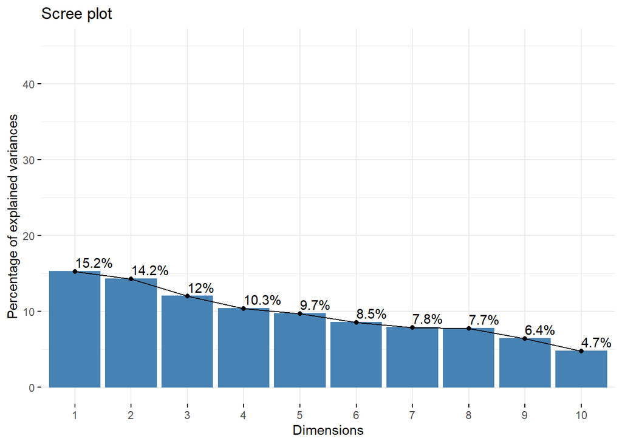

```r
fviz_screeplot(mca, addlabels = TRUE, ylim = c(0, 45))
```

- **Biplot**

The plot below shows a global pattern within the data. The function **fviz_mca_biplot()** can also be used to draw the biplot of individuals and variable categories. Here, we use the standard plot() function.

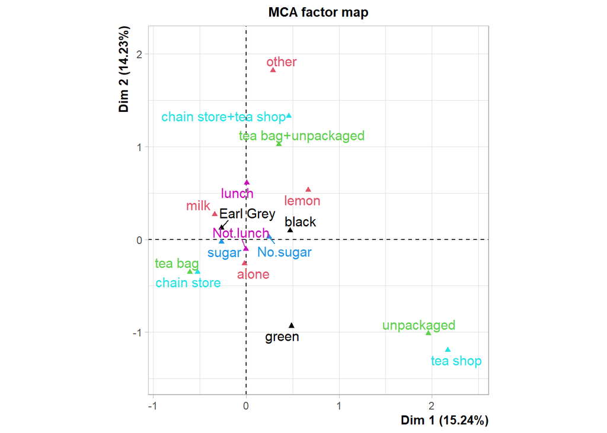

```r
# visualize MCA
plot(mca, invisible=c("ind"), habillage = "quali")
```

**Comments:** * The distance between variable categories gives a measure of their similarity. * For example, tea bad and chain store are more similar than black and lemon, and green is different from all the other categories.

- **Correlation between variables and principal dimensions**

To visualize the correlation between variables and MCA principal dimensions, we use:

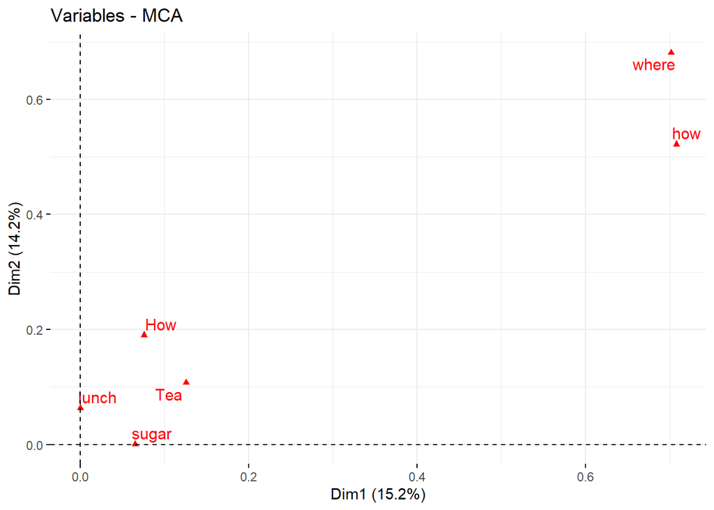

```r
fviz_mca_var(mca, choice = "mca.cor",
            repel = TRUE, # Avoid text overlapping (slow)
            ggtheme = theme_minimal())
```